# Chapter 9 — Measures of Dispersion

←Back to the bookChapter 9 · Measures of Dispersion

Part II · Describing Data | Chapter 9

Measures of Dispersion 🐍 Notebook

Five demos on how spread out the data is: range and IQR, variance and standard deviation built from scratch, the 68-95-99.7 rule, the box-plot outlier test, and the coefficient of variation.

Author: **John Fisher** · Statistics, Data Science and AI: A Visual Handbook · 2026

### 🎯 What you'll build in this notebook

| # | Demo | Idea it builds |
| --- | --- | --- |
| 1 | Same mean, different spread | why the average alone can mislead |
| 2 | Variance & SD from scratch | deviations, squaring, and n vs n−1 |
| 3 | The 68-95-99.7 rule | reading the standard deviation |
| 4 | Box plot & the outlier test | SD vs IQR when an outlier appears |
| 5 | Coefficient of variation | comparing spread across different scales |

## ⚙️ Setup, imports & the book's plotting style

```python
import numpy as np
import pandas as pd
import matplotlib.pyplot as plt

rng = np.random.default_rng(9)

NAVY="#0a1230"; INK="#1a2138"; INK_SOFT="#4a5578"
CYAN="#0891b2"; PURPLE="#7c3aed"; AMBER="#d97706"; GREEN="#059669"; PINK="#db2777"; BLUE="#2563eb"; GRID="#e6e9f2"
plt.rcParams.update({
    "figure.facecolor":"white","axes.facecolor":"white","figure.dpi":110,"font.size":11,
    "axes.edgecolor":GRID,"axes.linewidth":1.2,"axes.grid":True,"grid.color":GRID,"axes.axisbelow":True,
    "axes.spines.top":False,"axes.spines.right":False,"axes.titlesize":15,"axes.titleweight":"bold","axes.titlecolor":INK,
    "axes.labelcolor":INK_SOFT,"axes.labelsize":11.5,"xtick.color":INK_SOFT,"ytick.color":INK_SOFT,"legend.frameon":False,
})
def titlecard(ax,t,sub=None):
    ax.set_title(t, loc="left", pad=18)
    if sub: ax.text(0,1.02,sub,transform=ax.transAxes,fontsize=10.5,color=INK_SOFT,va="bottom")
print("✅ Environment ready.")
```

```
✅ Environment ready.
```

DEMO 1 · WHY SPREAD MATTERS

⚖️ Same average, very different stories

Two classes can share an identical mean score yet be worlds apart. Dispersion is what the mean hides.

```python
A = pd.Series([70, 72, 75, 78, 80])    # steady class
B = pd.Series([50, 60, 75, 90, 100])   # all over the place
print(f"Class A: mean {A.mean():.0f}, range {A.max()-A.min()}, SD {A.std(ddof=1):.1f}")
print(f"Class B: mean {B.mean():.0f}, range {B.max()-B.min()}, SD {B.std(ddof=1):.1f}")
print("Same mean (75), but B is far more spread out.")
```

```
Class A: mean 75, range 10, SD 4.1
Class B: mean 75, range 50, SD 20.6
Same mean (75), but B is far more spread out.
```

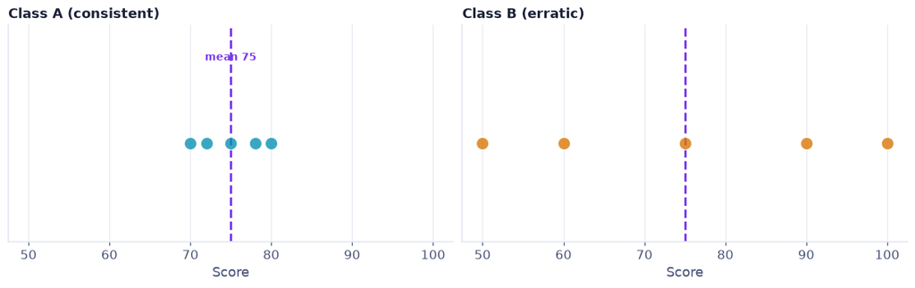

```python
fig,(a1,a2)=plt.subplots(1,2,figsize=(11,3.4),sharex=True,constrained_layout=True)
for ax,data,name,c in [(a1,A,"Class A (consistent)",CYAN),(a2,B,"Class B (erratic)",AMBER)]:
    ax.scatter(data, [1]*len(data), s=120, color=c, alpha=0.8, edgecolor="white", zorder=3)
    ax.axvline(75, color=PURPLE, ls="--", lw=2)
    ax.set_title(name, loc="left", fontsize=12, fontweight="bold", color=INK)
    ax.set_yticks([]); ax.set_ylim(0.5, 1.6); ax.set_xlabel("Score")
a1.text(75, 1.42, "mean 75", color=PURPLE, ha="center", fontsize=9, fontweight="bold")
plt.show()
```

DEMO 2 · VARIANCE & SD FROM SCRATCH

📐 Deviations, squared, averaged, rooted

Variance averages the squared distances from the mean. Standard deviation square-roots it back into the data's own units.

```
values     : [4 8 6 5 7]
deviations : [-2.  2.  0. -1.  1.]  (sum = 0.0 )
squared    : [4. 4. 0. 1. 1.]

Population variance (÷n)   = 2.00   -> SD = 1.41
Sample variance     (÷n-1) = 2.50   -> SD = 1.58
NumPy check: np.std(x, ddof=1) = 1.58
```

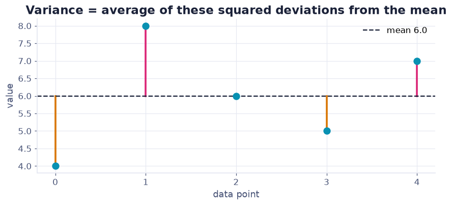

```python
x = np.array([4, 8, 6, 5, 7])
mean = x.mean()
dev  = x - mean                 # deviations from the mean (they always sum to 0)
sq   = dev**2                   # square so they do not cancel, and big gaps count more

print("values     :", x)
print("deviations :", dev, " (sum =", dev.sum(), ")")
print("squared    :", sq)
print()
var_pop  = sq.mean()            # divide by n   (whole population)
var_samp = sq.sum()/(len(x)-1)  # divide by n-1 (sample estimate, Bessel's correction)
print(f"Population variance (÷n)   = {var_pop:.2f}   -> SD = {np.sqrt(var_pop):.2f}")
print(f"Sample variance     (÷n-1) = {var_samp:.2f}   -> SD = {np.sqrt(var_samp):.2f}")
print(f"NumPy check: np.std(x, ddof=1) = {np.std(x, ddof=1):.2f}")

# --- added visual ---
import matplotlib.pyplot as plt, numpy as np
_CY,_PU,_AM,_GR,_PK,_INK,_GRY,_BL = "#0891b2","#7c3aed","#d97706","#059669","#db2777","#1a2138","#c7ccda","#2563eb"
idxs = np.arange(len(x))
fig, ax = plt.subplots(figsize=(8, 3.8))
ax.axhline(mean, color=_INK, lw=1.5, ls="--", label=f"mean {mean:.1f}")
for i, v in zip(idxs, x):
    ax.plot([i, i], [mean, v], color=_PK if v >= mean else _AM, lw=2.4, zorder=1)
ax.scatter(idxs, x, s=70, color=_CY, zorder=3)
ax.set_xticks(idxs); ax.set_xlabel("data point"); ax.set_ylabel("value"); ax.legend()
ax.set_title("Variance = average of these squared deviations from the mean")
plt.tight_layout(); plt.show()
```

**Why n−1?** The sample mean sits at the center of *its own* sample, so deviations from it run a touch too small. Dividing by the slightly smaller n−1 corrects that downward bias. For large samples the difference is tiny; it matters most when n is small.

DEMO 3 · THE 68-95-99.7 RULE

🔔 What the standard deviation means

For roughly bell-shaped data, about 68% of values fall within 1 SD of the mean, 95% within 2, and 99.7% within 3. The SD becomes a ruler for "how unusual is this?"

```python
data = rng.normal(100, 15, 100_000)   # mean 100, SD 15 (like IQ scores)
mu, sd = data.mean(), data.std()
for k in (1, 2, 3):
    pct = np.mean(np.abs(data-mu) < k*sd) * 100
    cheb = (1 - 1/k**2) * 100 if k>1 else 0
    print(f"within {k} SD: {pct:4.1f}%  (empirical-rule target ~{[68,95,99.7][k-1]}%, Chebyshev floor ≥{cheb:.0f}%)")
```

```
within 1 SD: 68.2%  (empirical-rule target ~68%, Chebyshev floor ≥0%)
within 2 SD: 95.4%  (empirical-rule target ~95%, Chebyshev floor ≥75%)
within 3 SD: 99.7%  (empirical-rule target ~99.7%, Chebyshev floor ≥89%)
```

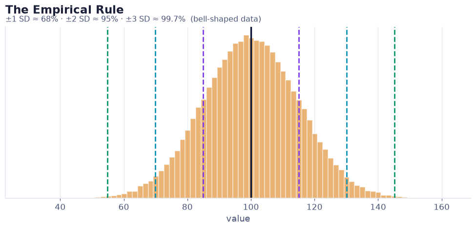

```python
fig,ax=plt.subplots(figsize=(9,4.4))
ax.hist(data, bins=80, color=AMBER, alpha=0.55, edgecolor="white")
for k,c in [(1,PURPLE),(2,CYAN),(3,GREEN)]:
    ax.axvline(mu-k*sd, color=c, ls="--", lw=1.8)
    ax.axvline(mu+k*sd, color=c, ls="--", lw=1.8)
ax.axvline(mu, color=NAVY, lw=2.2)
titlecard(ax,"The Empirical Rule","±1 SD ≈ 68% · ±2 SD ≈ 95% · ±3 SD ≈ 99.7%  (bell-shaped data)")
ax.set_xlabel("value"); ax.set_yticks([])
plt.tight_layout(); plt.show()
```

**Chebyshev's bonus:** even for *any* shape of data (not just bell curves), at least 75% of values lie within 2 SD and at least 89% within 3 SD. Weaker guarantees, but they always hold. And **z = (x − mean) / SD** tells you how many SDs from the mean a value sits, the idea behind the z-score we use later.

DEMO 4 · THE OUTLIER TEST

📦 Box plots, and SD vs IQR

The box plot draws the five-number summary and flags outliers beyond 1.5×IQR. Watch how one outlier balloons the SD while the IQR barely moves.

```python
salaries = pd.Series([42, 45, 48, 50, 47, 44, 46])      # $k
with_ceo = pd.concat([salaries, pd.Series([1000])], ignore_index=True)

def iqr(s): return s.quantile(.75) - s.quantile(.25)
print(f"Team only : SD {salaries.std(ddof=1):6.1f},  IQR {iqr(salaries):.1f}")
print(f"+ the CEO : SD {with_ceo.std(ddof=1):6.1f},  IQR {iqr(with_ceo):.1f}")
print("The SD exploded; the IQR hardly noticed. IQR is the robust choice.")
```

```
Team only : SD    2.6,  IQR 3.0
+ the CEO : SD  337.3,  IQR 3.8
The SD exploded; the IQR hardly noticed. IQR is the robust choice.
```

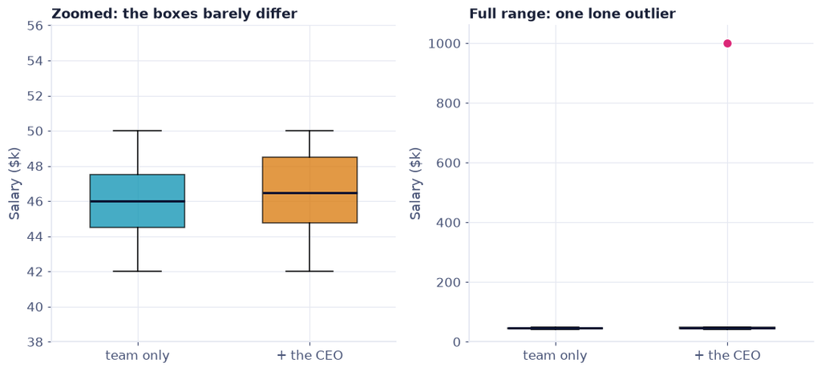

```python
# Two views: zoomed in (so the boxes are readable) and full range (so the outlier shows)
fig,(a1,a2)=plt.subplots(1,2,figsize=(10,4.6))
for ax in (a1,a2):
    bp=ax.boxplot([salaries, with_ceo], patch_artist=True, widths=0.55,
                  medianprops=dict(color=NAVY, linewidth=2),
                  flierprops=dict(marker="o", markerfacecolor=PINK, markersize=8, markeredgecolor="white"))
    for patch,c in zip(bp["boxes"],[CYAN,AMBER]): patch.set_facecolor(c); patch.set_alpha(0.75)
    ax.set_xticks([1,2]); ax.set_xticklabels(["team only","+ the CEO"]); ax.set_ylabel("Salary ($k)")
a1.set_ylim(38, 56)
a1.set_title("Zoomed: the boxes barely differ", loc="left", fontsize=11.5, fontweight="bold", color=INK)
a2.set_ylim(0, 1060)
a2.set_title("Full range: one lone outlier", loc="left", fontsize=11.5, fontweight="bold", color=INK)
plt.tight_layout(); plt.show()
```

DEMO 5 · COEFFICIENT OF VARIATION

📊 Comparing spread across different scales

Is height more variable than weight? They use different units, so raw SD can't be compared. The coefficient of variation (CV = SD / mean) is unitless, so it can.

```python
heights = rng.normal(170, 7,  500)    # cm
weights = rng.normal(70, 12,  500)    # kg

for name, s in [("Height (cm)", heights), ("Weight (kg)", weights)]:
    cv = s.std(ddof=1) / s.mean() * 100
    print(f"{name:<12}: mean {s.mean():6.1f}, SD {s.std(ddof=1):5.1f}, CV {cv:5.1f}%")
print("\nWeight has the larger CV, so it is RELATIVELY more variable, even though the numbers look smaller.")
print("Caution: CV only makes sense for positive data on a ratio scale (a true zero).")
```

```
Height (cm) : mean  169.7, SD   6.9, CV   4.1%
Weight (kg) : mean   70.1, SD  12.0, CV  17.1%

Weight has the larger CV, so it is RELATIVELY more variable, even though the numbers look smaller.
Caution: CV only makes sense for positive data on a ratio scale (a true zero).
```

## 🚚 Real-World Example: Two Carriers, Same Average

The measures so far used small arrays. Here they settle a real question: two shipping carriers average about the same delivery time, so which should you trust? The **mean** cannot tell them apart, but the **spread** can. Watch the standard deviation, IQR, range, and coefficient of variation separate the dependable carrier from the erratic one.

```
           mean    SD   IQR  rng    CV
carrier
SwiftShip  4.94  0.81  1.17  3.9  0.16
ValuePost  5.03  2.32  3.40  9.6  0.46
Same average, very different spread: SwiftShip is consistent, ValuePost is a gamble.
```

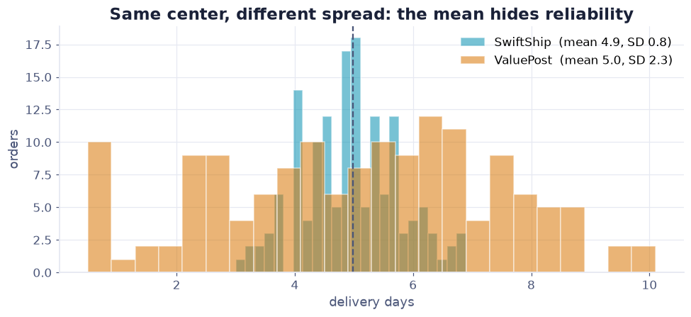

```python
# --- Real-World beat: dispersion tells two same-mean carriers apart ---
BASE = "https://raw.githubusercontent.com/johnfisher-ai/Statistics-Data-Science-AI-Visual-Book/main/data/"
try:    deliv = pd.read_excel("../../data/measures-of-dispersion--delivery_times.xlsx", sheet_name="Data")
except FileNotFoundError: deliv = pd.read_excel(BASE+"measures-of-dispersion--delivery_times.xlsx", sheet_name="Data")
g = deliv.groupby("carrier").delivery_days
summary = g.agg(mean="mean", SD="std", IQR=lambda s: s.quantile(.75)-s.quantile(.25), rng=lambda s: s.max()-s.min())
summary["CV"] = g.std() / g.mean()
print(summary.round(2).to_string())
print("Same average, very different spread: SwiftShip is consistent, ValuePost is a gamble.")
fig, ax = plt.subplots(figsize=(9,4.2))
for c, col in [("SwiftShip", CYAN), ("ValuePost", AMBER)]:
    s = deliv[deliv.carrier==c].delivery_days
    ax.hist(s, bins=24, alpha=0.55, color=col, edgecolor="white", label=f"{c}  (mean {s.mean():.1f}, SD {s.std():.1f})")
ax.axvline(deliv.delivery_days.mean(), color=INK_SOFT, ls="--", lw=1.5)
ax.set_title("Same center, different spread: the mean hides reliability")
ax.set_xlabel("delivery days"); ax.set_ylabel("orders"); ax.legend()
plt.tight_layout(); plt.show()
```

🎓 Recap

- **Dispersion** tells you what the mean hides: how spread out the data is.
- **Range** and **IQR** are quick; IQR (and the box plot) resist outliers.
- **Variance** averages squared deviations; **SD** roots it back into real units. Use n−1 for a sample.
- For bell-shaped data the **68-95-99.7 rule** turns SD into a ruler; Chebyshev gives looser limits for any shape.
- **CV** compares relative spread across different units, when the data is positive with a true zero.

Statistics, Data Science and AI: A Visual Handbook · © 2026 John Fisher

←Back to the bookChapter 9 · Measures of Dispersion